# Data quality and pre-process transaction analyisis

Joan Claverol - Data mentor

02/10/2019

```r
# libraries ---------------------------------------------------------------
if (require(pacman) == FALSE) {
  install.packages("pacman")
}

pacman::p_load(
  tidyverse, lubridate, magrittr,
  knitr, kableExtra, # nice tables in RMarkdown
  arules, arulesViz, # machine learning
  )
```

# Data quality

We want to be sure of our transaction data set before we start our analysis. The data set **line items.csv** and **orders.csv** will help us to define which are the transaction we must keep to keep on with our analysis. At the end of the data quality, we are supposed to have our transaction data set only with the right transactions:

```r
# data --------------------------------------------------------------------

# line items
line_item <- read_csv2(file = "../data/clean_data/lineitems.csv",
                       col_types = cols(
                         id = col_integer(),
                         id_order = col_integer(),
                         product_id = col_integer(),
                         product_quantity = col_integer()
                       ))

# orders
orders <- read_csv2("../data/clean_data/orders_translated.csv",
                     col_types = cols(
                       id_order = col_integer()
                     ))

# transactions
trans <- read_delim("../data/clean_data/trans.csv", delim = ";")
```

## Missing values

### Line items file

```r
kable(line_item %>%
  summarise_all(~sum(is.na(.))) %>%
  gather(key = "Variable", value = "Number of NA")) %>%
  kable_styling(bootstrap_options = "striped", full_width = F)
```

| Variable | Number of NA |
| --- | --- |
| id | 0 |
| id_order | 0 |
| product_id | 0 |
| product_quantity | 0 |
| sku | 0 |
| date | 0 |
| unit_price | 0 |

### Orders file

```r
kable(orders %>%
  summarise_all(~sum(is.na(.))) %>%
  gather(key = "Variable", value = "Number of NA")) %>%
  kable_styling(bootstrap_options = "striped", full_width = F)
```

| Variable | Number of NA |
| --- | --- |
| id_order | 0 |
| created_date | 0 |
| state | 0 |
| total_paid | 5 |

There are 5 missing values in total paid column, they represent a 0.002204% of the data. Let’s explore a little bit them, but the best solution would be to extract them out from the data:

```r
kable(orders %>%
  filter(is.na(total_paid))) %>%
  kable_styling(bootstrap_options = "striped", full_width = F)
```

| id_order | created_date | state | total_paid |
| --- | --- | --- | --- |
| 427314 | 2017-11-20 18:54:39 | Pending | NA |
| 431655 | 2017-11-22 12:15:24 | Pending | NA |
| 447411 | 2017-11-27 10:32:37 | Pending | NA |
| 448966 | 2017-11-27 18:54:15 | Pending | NA |
| 449596 | 2017-11-27 21:52:08 | Pending | NA |

As the status of the orders is *Pending*, would not affect our analysis, as we are only focused on the *Completed*.

### Transaction file

```r
kable(trans %>%
  summarise_all(~sum(is.na(.))) %>%
  gather(key = "Variable", value = "Number of NA")) %>%
  kable_styling(bootstrap_options = "striped", full_width = F)
```

| Variable | Number of NA |
| --- | --- |
| items | 0 |

## Check information between **orders.csv** and **trans.csv**

### Same amount of transactions

First, let’s check how many transactions do we have in the **trans.csv** file:

- 10453 transactions

Now we have to check it this corresponds to the total number of completed orders. To find out this information we should know:

- The transaction files only contains transactions with **more** than 1 item.
- All the transactions has been **completed**.

```r
# We are going to look which transactions are the ones that are
# completed, and we are going to store them in a vector
orders %>%
  filter(state == "Completed") -> temp
completed_orders <- unique(temp$id_order)

# then we are going to look at the file of line items, where we can check
# how many products have been sold by transaction. We know that out transaction
# file does not include transactions smaller than two products. So when we
# get the total number of products sold by transaction, we filter the ones that
# are smaller than two and we select the only ones that has been completed, we
# found the same amount of unique orders than transactions
trans_orders <- line_item %>%
  group_by(id_order) %>%
  summarise(num_prod = n()) %>%
  filter(num_prod > 1, id_order %in% completed_orders)

kable(trans_orders %>%
  summarise("Completed transactions orders.csv" = n())) %>%
  kable_styling(bootstrap_options = "striped", full_width = F)
```

| Completed transactions orders.csv |
| --- |
| 10453 |

Yes, we can extract the same number of transactions for **trans.csv** than **orders.csv**.

### Check total paid in **orders.csv** and total price in **line items.csv**

We are assuming the *total paid* variable in our **orders.csv** file will be exactly the same than the *total price* in **line items.csv**. Let’s check this:

```r
# total paid in completed orders
completed_orders <- orders %>%
  filter(state == "Completed")
# summary total paid in orders.csv
temp_orders <- completed_orders %>%
  summarise("Sum total paid in orders.csv" = sum(total_paid))
# summary tota price in lineitems.csv
temp_lineitems <- line_item %>%
    arrange(date) %>%
    filter(id_order %in% completed_orders$id_order) %>%
    mutate(total = product_quantity*unit_price) %>%
    summarise("Sum total price in line items.csv" = sum(total))
# table to show the difference
kable(temp_orders %>%
  bind_cols(temp_lineitems) %>%
  mutate(
    difference = `Sum total paid in orders.csv` - `Sum total price in line items.csv`)) %>%
  kable_styling(bootstrap_options = "striped", full_width = F)
```

| Sum total paid in orders.csv | Sum total price in line items.csv | difference |
| --- | --- | --- |
| 15910079 | 15709707 | 200372.2 |

The difference is quite big. We will take a deeper look into the distribution of the differences between the two files:

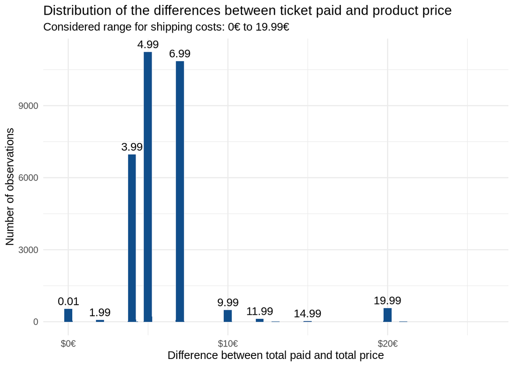

```r
# creating a dataframe to check if total_paid is equal to total_unit_price
line_item_total <- line_item %>%
  filter(id_order %in% completed_orders$id_order) %>%
  mutate(total_units_price = product_quantity*unit_price) %>%
  group_by(id_order) %>%
  summarise(total_price = sum(total_units_price))

# filter all the differences different than 0
differents_than_0 <- completed_orders %>%
   left_join(line_item_total, by = "id_order") %>%
   mutate(difference = round(total_paid - total_price, 2)) %>%
   filter(difference != 0) %>% nrow(.)

# create difference vairable and filter the values different than 0 and between
# an expected range considered as shipping costs
orders_vs_lineItem <- completed_orders %>%
  left_join(line_item_total, by = "id_order") %>%
  mutate(difference = round(total_paid - total_price, 2)) %>%
  filter(between(difference, 0, 30), difference != 0)

# groupe all the observations by each product price
orders_vs_lineItem_group <- orders_vs_lineItem %>%
  group_by(difference) %>%
  summarise(n = n())

# looking at the difference distribution
orders_vs_lineItem_group %>%
  ggplot(aes(x = difference)) +
    geom_col(aes(y = n), fill = "dodgerblue4", width = 0.5) +
    geom_text(aes(
      y = if_else(
        as.character(difference) %in% c("1.99","3.99","4.99","6.99","9.99","0.01",
                                        "19.99","11.99","14.99"),
        n, NULL),
         label = difference, vjust = -0.5)) +
    scale_x_continuous(labels = scales::dollar_format(suffix = "€")) +
    xlab("Difference between total paid and total price") +
    ylab("Number of observations") +
    labs(
      title = "Distribution of the differences between ticket paid and product price",
      subtitle = "Considered range for shipping costs: 0€ to 19.99€") +
    theme_minimal()
```

If we consider a range between 0€ and 19.99€ as a delivery cost, we explain 98.11 % of the tickets with a difference between ticket paid and product price bigger than 0.

# Data pre-process

## Find clusters in the data

After creating a new feature called *difference*, we can find different groups inside the data:

- If the difference is 0, there are no shipping costs, so we will give them the value **no_ship_costs**
- If the difference is between 0 and 19.99, the label will be **ship_costs**
- If the difference is higher than 19.99, then the label will be **unknown**

Let’s find out which percentage of the data represent each group:

```r
# select all the transactions with a difference equal to 0
orders_group <- completed_orders %>%
  left_join(line_item_total, by = "id_order") %>%
  filter(state == "Completed") %>%
  mutate(difference = round(total_paid - total_price, 2),
         trans_groups = if_else(
           difference == 0, "no_ship_costs",
           if_else(between(difference, 0, 19.99),"ship_costs","unknown"))) %>%
  drop_na() # strange missing values
# show a table with the proportion of the data for each group
kable(orders_group %>%
  group_by(trans_groups) %>%
  summarise(count = n()) %>%
  arrange(desc(count)) %>%
  mutate(frequency = paste(round(count/sum(count),4)*100, "%"))) %>%
  kable_styling(bootstrap_options = "striped", full_width = F)
```

| trans_groups | count | frequency |
| --- | --- | --- |
| ship_costs | 31891 | 68.49 % |
| no_ship_costs | 14002 | 30.07 % |
| unknown | 667 | 1.43 % |

Time to see the distribution of total paid by each group, excluding the unknown label:

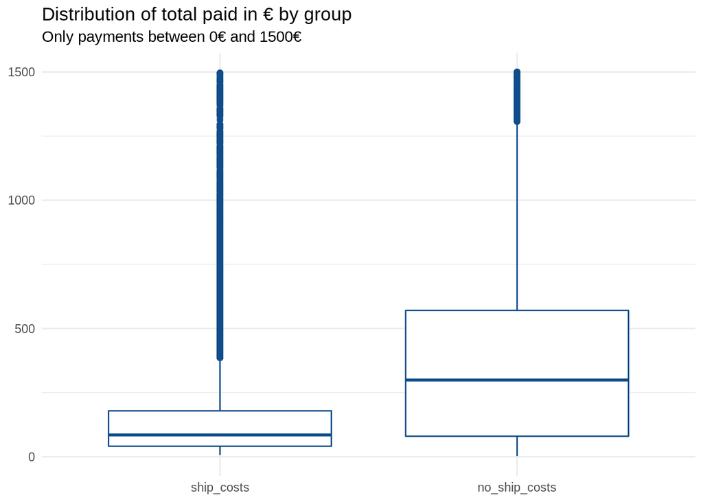

```r
# plot total income in shop
orders_group %>%
  filter(trans_groups != "unknown") %>%
  ggplot(aes(y = total_paid, x = reorder(trans_groups, total_paid))) +
    geom_boxplot(color = "dodgerblue4") +
    scale_y_continuous(labels = scales::dollar_format(prefix = "€")) +
    ylim(0, 1500) +
    labs(title = "Distribution of total paid in € by group",
         subtitle = "Only payments between 0€ and 1500€") +
    theme_minimal() +
    theme(
      axis.title = element_blank()
    )
```

The distribution without shipping costs are much bigger than the other ones, specially the ones with shipping costs. Maybe these have been done in a store, where people tend to spend higher amounts of money.

This can lead us to do different market basket analysis in relation to these groups.

## Transactions preparation

We will have to add the transaction id in the **transactions.csv** to find out which is the right transaction for each group. We already know that all the files has been extracted following the same order, so after excluding all the orders smaller than 2 items and only selecting the completed ones, we will be able to add the order id:

```r
# select orders id completed in orders.csv
completed_orders <- orders %>%
  filter(state == "Completed") %>%
  distinct(id_order, .keep_all = T)

# find out the id order by each completed order
transaction_id <- line_item %>%
  group_by(id_order) %>%
  summarise(product_quantity = n()) %>%
  filter(product_quantity > 1, id_order %in% completed_orders$id_order) %>%
  left_join(completed_orders %>% select(id_order, total_paid), by = "id_order")

# add the transacitons information
transaction_with_id <- trans %>%
  mutate(id_order = transaction_id$id_order,
         product_quantity = transaction_id$product_quantity,
         total_paid = transaction_id$total_paid) %>%
  select(id_order, total_paid, product_quantity, items)
# show the table
kable(head(transaction_with_id, 10)) %>%
  kable_styling(bootstrap_options = "striped", full_width = F)
```

| id_order | total_paid | product_quantity | items |
| --- | --- | --- | --- |
| 246018 | 211.95 | 4 | IFX0049,TUC0302,IFX0014,MOP0083 |
| 246405 | 407.96 | 4 | CRU0045,OWC0048,SEA0038,APP1130 |
| 251302 | 140.99 | 2 | APP0405,APP1208 |
| 251688 | 505.76 | 5 | BOS0059,APP1457,APP0432,APP2487,APP2552 |
| 253220 | 1610.00 | 5 | LGE0038,ELA0004,APP1459,APP1208,LAC0221 |
| 253306 | 497.68 | 2 | APP2498,APP1916 |
| 253307 | 292.04 | 5 | LAC0166,ALL0004,WOE0002,APP2523,SAN0150 |
| 254341 | 34.98 | 2 | BEZ0209,SAT0024 |
| 254816 | 283.83 | 3 | APP1037,LAC0176,SAT0003 |
| 258155 | 40.76 | 2 | EVU0003,SAN0039 |

We can see the quantity of the products is the same that the number of items in the transaction. We can trust on the transaction id now.

It’s time to create groups of transactions. One with shipping costs, and the other without:

```r
# selecting transaction shipped
orders_ship_cost <- orders_group %>%
  filter(trans_groups == "ship_costs")
trans_shipped <- transaction_with_id %>%
  filter(id_order %in% orders_ship_cost$id_order) %>%
  select(items) %>%
  write_csv2("../data/clean_data/transactions/trans_shipped.csv")
# selecting transaction in store
orders_in_store <- orders_group %>%
    filter(trans_groups == "no_ship_costs")
trans_no_shipped <- transaction_with_id %>%
  filter(id_order %in% orders_in_store$id_order) %>%
  select(items) %>%
  write_csv2("../data/clean_data/transactions/trans_no_shipped.csv")
```

Now we have two transaction files:

- Transaction files with delivery costs with 6665 transactions.
- Transaction files without delivery costs with 3484 transactions.